# Lista 1 TRI

Davi Wentrick Feijó - 200016806

2023-09-11

### Questao 1

Com base nos coeficientes estudados, você vê algum item que deva ser descartado? Justifique sua resposta.

```r
# Questao 1

# correlação ponto-bisserial
rho.PB <- altura.desc$bisCorr

# correlação bisserial
rho.B.vec <- rep(0,14)

for (i in 1:14) {
  pp <- colSums(altura.itens)[i]/nrow(altura.itens)
  rho.B <- sqrt(pp*(1-pp))*altura.desc$bisCorr[i]/dnorm(qnorm(pp,0,1),0,1)
  rho.B.vec[i] <- rho.B
}
kable(data.frame(rho.PB, rho.B.vec),
      col.names = c("Ponto-bisserial", "Bisserial"), align = "c")
```

|  | Ponto-bisserial | Bisserial |
| --- | --- | --- |
| i1 | 0.2469645 | 0.3217972 |
| i2 | 0.4787785 | 0.6568108 |
| i3 | 0.5458117 | 0.7725806 |
| i4 | 0.4268757 | 0.5750093 |
| i5 | 0.6221973 | 0.8948373 |
| i6 | 0.6104665 | 0.8685333 |
| i7 | 0.7003596 | 0.8787240 |
| i8 | 0.3418284 | 0.6224633 |
| i9 | 0.4668594 | 0.6069855 |
| i10 | 0.7115912 | 0.8925404 |
| i11 | 0.5425708 | 0.6875413 |
| i12 | 0.6627509 | 0.8380873 |
| i13 | 0.6306598 | 0.8440050 |
| i14 | 0.7274669 | 0.9500600 |

Como todos os valores obtidos sao positivos, nao temos indicios de que tenhamos que remover nenhums dos items

### Questao 2

Itens com valores maiores para o coeficiente de correlaçao ponto-bisserial tendem a apresentar maiores valores também para o coeficiente de correlaçaõo bisserial? Apresente um diagrama dedispersão com os valores dos dois coeficientes para os 14 itens.

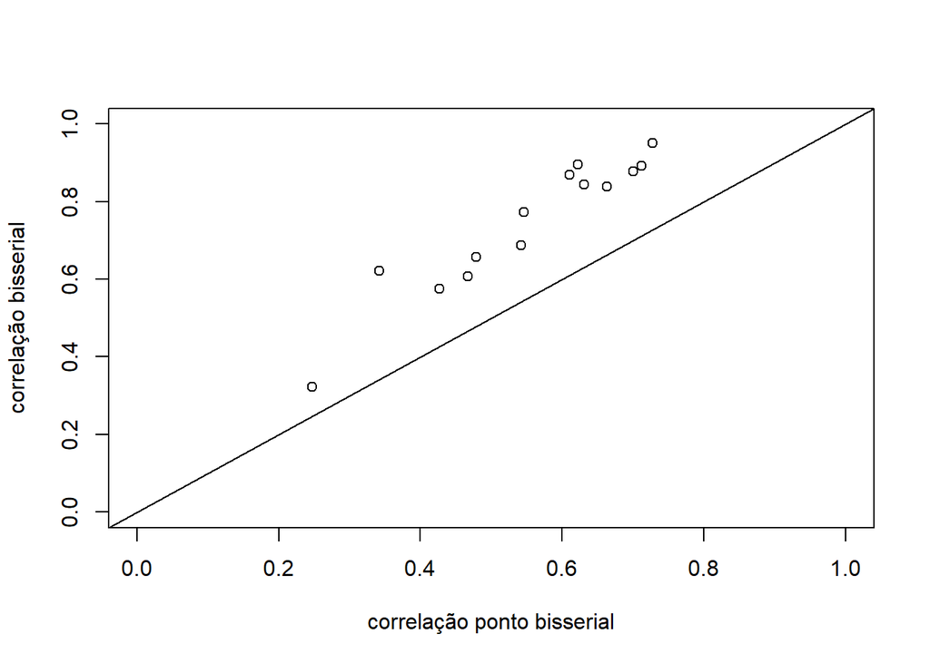

```r
# Questao 2

plot(altura.desc$bisCorr, rho.B.vec, xlab=c("correlação ponto bisserial"),
     ylab=c("correlação bisserial"),xlim=c(0,1),ylim=c(0,1))
abline(0,1)
```

Pelo gráfico podemos notar que existe uma correlacao positiva entre as duas medidas

### Questao 3

Uma alternativa para o escore total como medida de proficiência (altura, neste caso) seria o escore padronizado $Z_j =(T_j -T^{-})/S_T,j=1,…,n$.

- A partir dos valores do escore padronizado, obtenha uma estimativa da altura de cada indivíduo com a mesma média e desvio-padrão das alturas reais, isto é $Hj = \mu + \sigma Z_j , j = 1, . . . , n$, sendo a altura média real e o desvio-padrão da alturas reais.
- Calcule a correlação entre as alturas reais e estimadas.
- Elabore um diagrama de dispersão com as alturas reais e estimadas.

```r
# Questao 3

mu <- mean(altura$altura)
desvio <- sd(altura$altura)

t <- apply(altura.itens,1,sum)
t_media <- mean(t)
s <- sd(t)

## escore padronizado
zj <- (t-t_media)/s

## altura estimada
hj <- mu + desvio*zj

## correlação entre alturas reais e estimadas

(cor(altura$altura, hj))
```

```
## [1] 0.785007
```

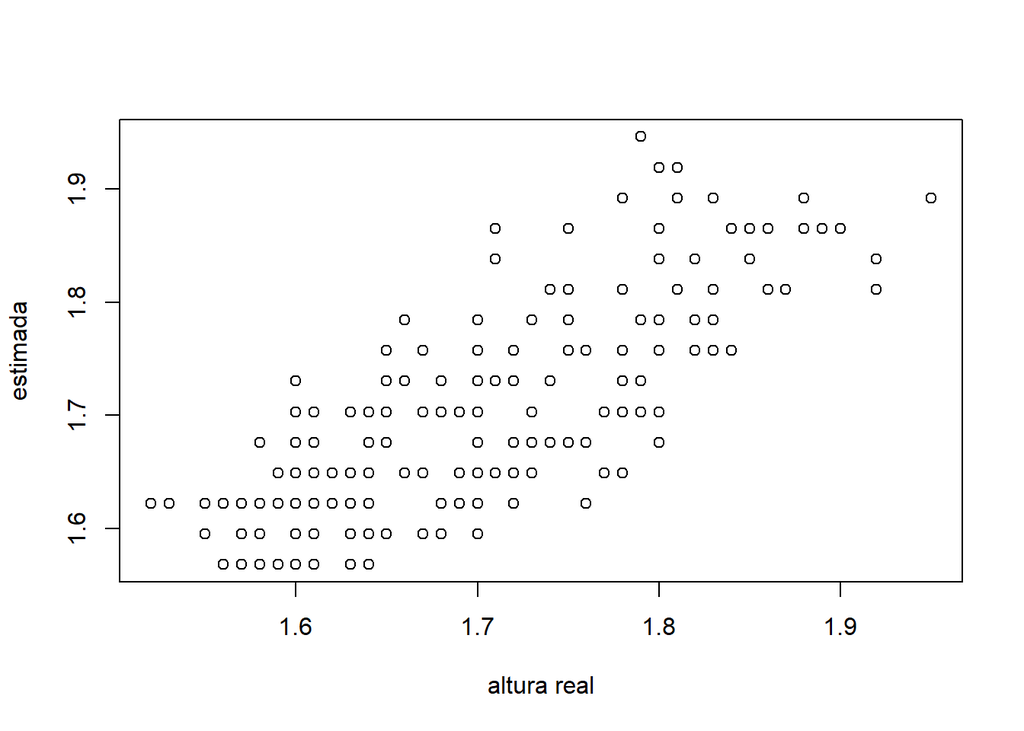

```r
plot(altura$altura, hj, xlab=c("altura real"),
     ylab=c("estimada"))
```

### Questao 4

Com base no coeficiente α de Cronbach, a consistência interna do questionário é satisfatória?

```r
# Questao 4

cronbach.alpha(altura.itens)
```

```
##
## Cronbach's alpha for the 'altura.itens' data-set
##
## Items: 14
## Sample units: 211
## alpha: 0.826
```

Como o valor obtido foi acima de 0.7 podemos dizer que está consistente

### Questao 5

Quais os itens com o menor e o maior índice de dificuldade?

```r
# Questao 5

(1-apply(altura.itens,2,sum)/nrow(altura.itens))
```

```
##        i1        i2        i3        i4        i5        i6        i7        i8
## 0.6777251 0.7582938 0.7914692 0.7345972 0.8056872 0.7962085 0.4691943 0.9194313
##        i9       i10       i11       i12       i13       i14
## 0.3270142 0.5260664 0.5971564 0.5876777 0.7251185 0.6824645
```

Podemos notar que o item 8 é o mais dificil e o item 9 é o mais facil

### Questao 6

Quais itens apresentam maior índice de discriminação entre indivíduos altos e baixos?

```r
# Questao 6

escore <- apply(altura.itens,1,sum)
aux <- ceiling(0.27*nrow(altura.itens))
escore.inf <- sort(escore)[aux]
escore.sup <- sort(escore)[nrow(altura.itens)-aux]

altura.inf <- altura.itens[escore<=escore.inf,]
altura.sup <- altura.itens[escore>=escore.sup,]

apply(altura.sup,2,sum)/nrow(altura.sup)-apply(altura.inf,2,sum)/nrow(altura.inf)
```

```
##        i1        i2        i3        i4        i5        i6        i7        i8
## 0.2473594 0.4625399 0.4939818 0.4505036 0.5278801 0.5642348 0.8936379 0.1719479
##        i9       i10       i11       i12       i13       i14
## 0.5408990 0.9081307 0.6467698 0.7919430 0.6394006 0.8160157
```

Os itens 10, 7 e 14 apresentam os maiores indices de discriminação.